# Exercise 3 - Updated

## Question 1 Discussed in Class, Skipped

## Question 2 Kernal Regression

#### Part (A)

Show the least square estimator in one predictor case can be written into the linear smoother form of $f(\hat{x^*})=\sum_{i=1} w_i(x_i,x^*)y_i$.
$$\begin{align}
\hat(y) &=X(X^TX)^{-1}X^Ty= Hy\\
\hat{y_i} &= \text{the $i$th element of $\hat{y}$}\\
&= \text{the $i$th row of $H$ multiply vector $y$}\\
&= \sum_j H_{ij}y_j \\
&= \sum_j w(x_j,x) y_j
\end{align}$$

$$\\$$
When $w_i=\frac{1}{K}$, $f(\hat{x})=\sum_{i=1}^K\frac{1}{K}y_i=\bar{y_{i,i\in\{1,2,,K\}}}$, takes the average among its K closest samples (K nearest neighbours), has the smoothing effect among neighbours to lower the impact of outliers.

#### Part (B)

Write a R module with Gaussian Kernal

```r
rm(list=ls())
set.seed(123)
library(modules)

#write module KernalRegression (kr)

kr <- module({
  import('stats')
  # given any x and h, calculate the kernal K
  K <- function(d,h){
    return(dnorm(x=d/h,mean=0,sd=1))
  }

  #input x and calculated normalized weights
  weights <- function(x,xi,h){
    w=K(x-xi,h)/h
    w=w/sum(w)
    return(w)
  }

  #calculate the weights use weights function and calculate y
  knsmooth <- function(x_new,x,y,h){
    w=sapply(x_new, function(t) weights(x,t,h))
    yks <- t(w) %*% y
    return(yks)
  }
})
```

Test it with simulations:

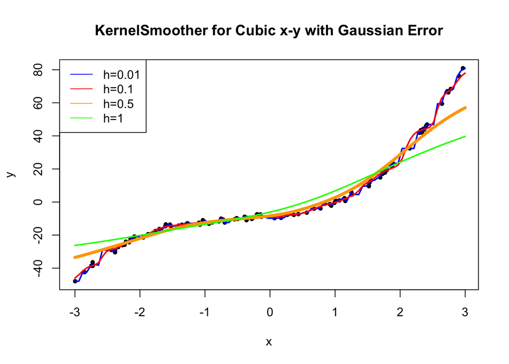

```r
x <- runif(100,-3,3)
eps <- rnorm(length(x),0,1)
y <- 2*x^3+3*x^2+4*x+eps
y <- y-mean(y)

#create x_new for prediction and plot
x_new= seq(-3,3,length.out = length(x))

#use the knsmooth function from kr module on simulated x and y and predict x_new
yks_0 <- kr$knsmooth(x_new,x,y,0.01)
yks_1 <- kr$knsmooth(x_new,x,y,0.1)
yks_2 <- kr$knsmooth(x_new,x,y,0.5)
yks_3 <- kr$knsmooth(x_new,x,y,1)

#plot the fitted curve
plot(x,y,pch=20,main='KernelSmoother for Cubic x-y with Gaussian Error')
lines(x_new,yks_0,type='l',col='blue',lwd=2)
lines(x_new,yks_1,type='l',col='red',lwd=2)
lines(x_new,yks_2,type='l',col='orange',lwd=4)
lines(x_new,yks_3,type='l',col='green',lwd=2)
legend('topleft',c('h=0.01','h=0.1','h=0.5','h=1'),lty=1,col=c('blue','red','orange','green'))
```

## Question 3 Cross Validation

#### Part (A)

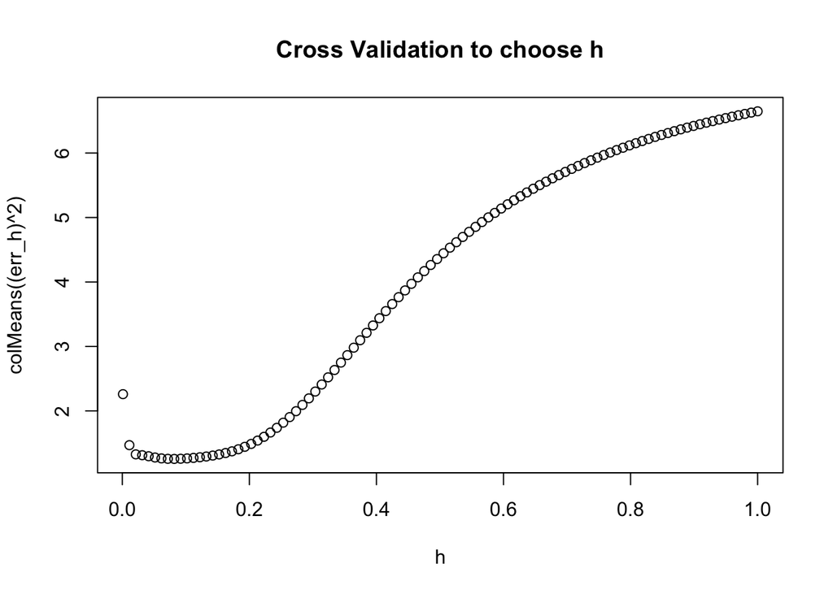

```r
#create training and test dataset
x <- runif(100,0,1)
eps <- rnorm(length(x),0,1)
y <- 2*x^3+3*x^2+4*x+eps
train <- as.data.frame(cbind(x,y))

xtest <- runif(100,0,1)
epstest <- rnorm(length(xtest),0,1)
ytest <- 2*xtest^3+3*xtest^2+4*xtest+epstest
test <- as.data.frame(cbind(xtest,ytest),colnames=c(x,y))

# write a function cv for cross validation
# input training set, test test and h
# output the kernal regression result of test set and error for each test y
cv <- function(train,test,h){
  yks_test <- kr$knsmooth(test$x,train$x,train$y,h)
  err <- test$y-yks_test
  return(list(yks_test=yks_test,err=err))
}

# try a bunch of different h for cross validation error
h <- seq(0.001,1,length.out = 100)
err_h = sapply(h,function (t) cv(train,test,t)$err)

# the sum of errors in absolute values in for each h
plot(h,colMeans((err_h)^2),main='Cross Validation to choose h')
```

```r
h[which.min(colMeans((err_h)^2))]
```

```
## [1] 0.08172727
```